# Introduction

GDP is the value of all final goods and services produced in a country within a given period. There are two sides to GDP, the demand side and the supply side:

- On the **demand side**, the **product approach to GDP** recognizes that total aggregate demand is made of four components:
  - Consumption spending by households (C).
  - Investment spending by households and corporations (I).
  - Government purchases (G).
  - Net exports (NX).
- On the **supply side**, the production of output involves the use of factor of production, often limited to capital and labor. These factors of production receive payment for their use, whose sum equals GDP.[^1] The **income approach to GDP** consists in dividing up these payments into the different factors of production. Again, this often simply means a division of total value added into capital income, and labor income.

# GDP: The Product Approach

GDP is equal to the total aggregate demand for goods:
$$Y = C + I + G + X -M.$$
We often define net exports as:[^2]
$$NX = X-M,$$
so that GDP is simply:
$$Y = C + I + G + NX.$$

We look at each component of aggregate demand in turn:

- Consumption (C)
- Investment (I)
- Government Purchases (G)
- Net Exports (NX)

## Personal Consumption Expenditures - Consumption (C)

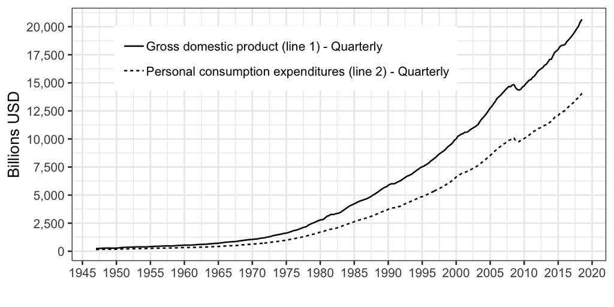

To get a better of sense of how big consumption is as a fraction to GDP (although you may eyeball it on this picture), we might plot consumption as a function of GDP, which is what I do below. You can see that Personal Consumption Expenditures are approximately **60 to 70 % of GDP**. You can also see that it’s been rising since the end of the sixties. We will discuss that.

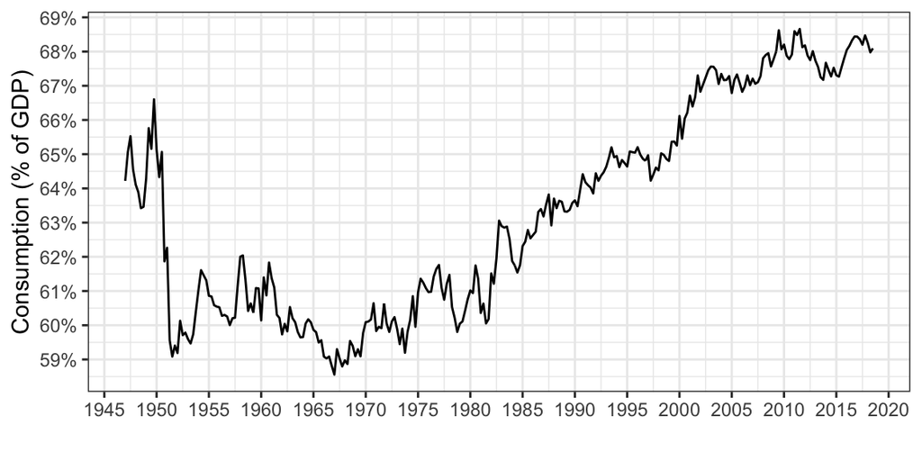

Personal Consumption Expenditures are divided up into:

- Durable Goods (more than 3 years of durability): e.g. cars.
- Non-durable Goods (less than 3 years of durability).
- Services.

Services have become more important than Goods in total consumption since the 1970s.

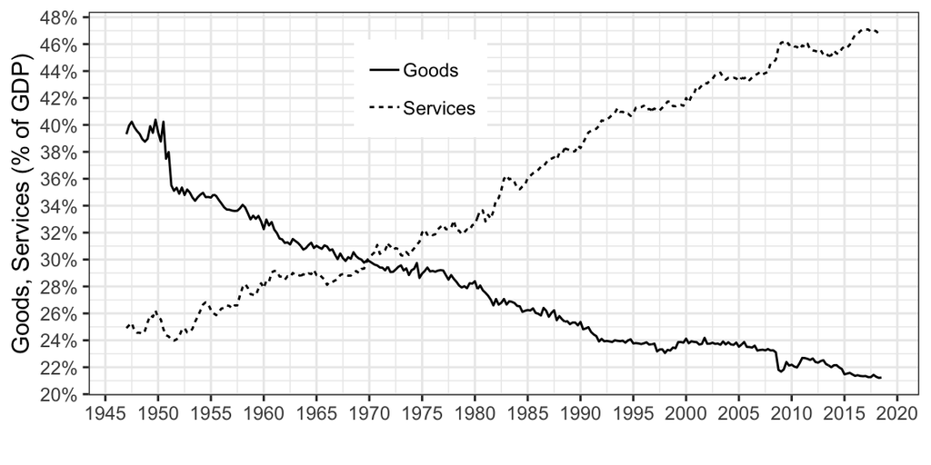

## Gross private domestic investment - Investment (I)

Investment has two components:

- non residential investment is the purchase of new capital goods by firms: structures, new plants.
- residential investment is the purchase of new houses.

Gross private domestic investment is approximately **15 to 20 % of GDP**, as you can see on Figure . It is also very volatile over the cycle.

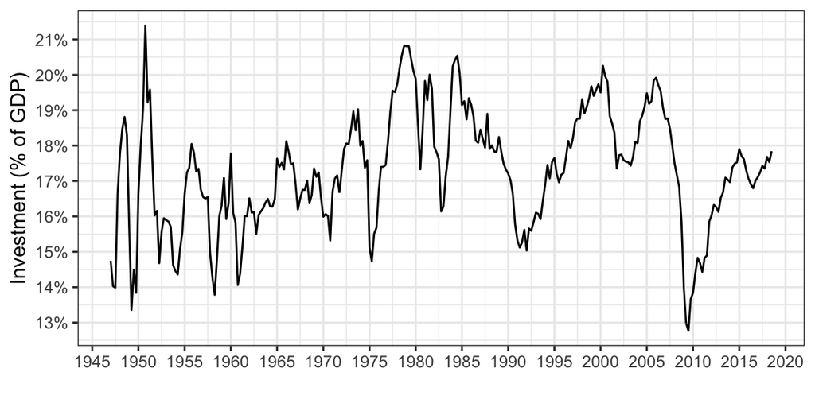

## Government Purchases (G)

Government purchases are composed of purchases of goods by the government plus the compensation of government employees. Overall, they comprise about approximately 20% of GDP, as can be seen on Figure . Note however that they do not include transfers from the government of interest payments on government debt.

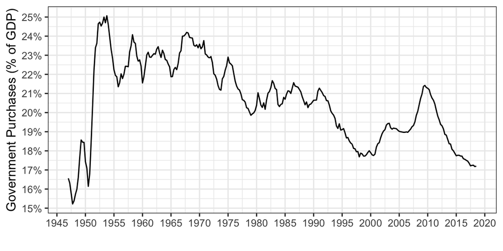

## Net Exports (NX)

Net exports of goods and services are approximately **-2 to -6 % of GDP**, at least in the modern period (and in the United States), as you can see on Figure .

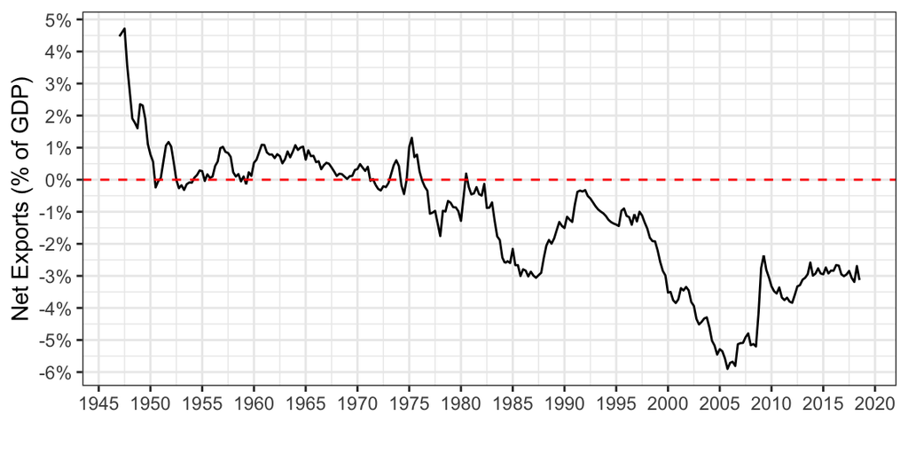

# GDP: The Income Approach

## Cobb Douglas Production function

In order to organize our thinking, let’s write out a Cobb-Douglas production function, defined as:
$$Y_t = A_t K_t^{\alpha} L_t^{1-\alpha},$$
where $\alpha$ is a number between $0$ and $1$. It is useful to then think of a firm which would choose the amount of labor it uses $L_t$ as well as the amount of capital it uses $K_t$ in order to maximize its profits:
$$\max_{K_t, L_t} \quad A_t K_t^{\alpha} L_t^{1-\alpha} - R_t K_t - w_t L_t,$$
In this expression, $R_t$ is the **rental rate** of capital, also called the **gross return** to capital. This represents how much it costs to rent one unit of capital. This cost actually has two components:

1. It includes a conventional interest rate $r_t$, which is the cost of borrowing money to invest in capital. You should think of this as the real interest rate which is charged by a bank to borrow money.
2. It also includes a component to account for depreciation of the capital stock, often denoted by $\delta$. If capital is bought, then the resale price for each unit of capital is lower by $\delta$, which is a cost to the investor. If capital is rented, then capital needs to be given back to the owner in its original state.

We have that the rental rate or gross return is equal to the net return plus the depreciation rate:
$$\boxed{R_t = r_t + \delta}.$$
From Econ 11, it should be clear that a way to solve this problem is to set the derivative of the profit function equal to $0$ with respect to $K_t$ and $L_t$:

- Differentiating with respect to $K_t$ implies:
  $$\alpha A_t K_t^{\alpha-1} L_t^{1-\alpha} - R_t = 0 \quad \Rightarrow \quad \boxed{R_t = \alpha A_t K_t^{\alpha-1} L_t^{1-\alpha}}.$$
- Differentiating with respect to $L_t$ implies:
  $$(1-\alpha) A_t K_t^{\alpha} L_t^{-\alpha} - w_t = 0 \quad \Rightarrow \quad \boxed{w_t = (1-\alpha) A_t K_t^{\alpha} L_t^{-\alpha}}$$

Note that an alternative, and more direct way to get at that same result, would be to use Econ 11 directly, and write that the marginal products have to be equal to prices:

- The **rental rate of capital** $R_t$ is the marginal product of capital. The marginal product of capital is how much more output is obtained when the capital stock is increased by one unit, which is just the derivative of output with respect to capital $\partial Y_t / \partial K_t$:
  $$\begin{aligned}
  R_t&=\frac{\partial Y_t}{\partial K_t}\\
  &= \frac{\partial \left(A_t K_t^{\alpha} L_t^{1-\alpha}\right)}{\partial K_t}\\
  R_t &= \alpha A_t K_t^{\alpha-1} L_t^{1-\alpha}
  \end{aligned}$$
- The **wage** $w_t$ is the marginal product of labor. The marginal product of labor is how much more output is obtained when the quantity of labor is increased by one unit, which is just the derivative of output with respect to labor $\partial Y_t / \partial L_t$:
  $$\begin{aligned}
  w_t &=\frac{\partial Y_t}{\partial L_t}\\
  &= \frac{\partial \left(A_t K_t^{\alpha} L_t^{1-\alpha}\right)}{\partial L_t}\\
  w_t &= (1-\alpha) A_t K_t^{\alpha} L_t^{-\alpha}
  \end{aligned}$$
  The total wage bill $w L_t$ is a fraction $1-\alpha$ of output $Y_t$:
  $$\begin{aligned}
  w_t L_t &= (1-\alpha) A_t K_t^{\alpha} L_t^{-\alpha} \cdot L_t \\
  &= (1-\alpha) A_t K_t^{\alpha} L_t^{1-\alpha}\\
  w_t L_t &= (1-\alpha) Y_t
  \end{aligned}$$

The total capital income $R_t K_t$ is a fraction $\alpha$ of output $Y_t$:
$$\begin{aligned}
R_t K_t &= \alpha A_t K_t^{\alpha-1} L_t^{1-\alpha} \cdot K_t \\
&= \alpha A_t K_t^{\alpha} L_t^{1-\alpha}\\
R_t K_t &= \alpha Y_t.
\end{aligned}$$
This implies that the share of capital income in output (or equivalently, value added) is:
$$\frac{R_t K_t}{Y_t}=\alpha,$$
while the share of labor income in output (or equivalently, value added) is:
$$\frac{w_t L_t}{Y_t}=1-\alpha.$$
Note that capital income plus labor income equals total output:
$$R_t K_t + w_t L_t = Y_t.$$
Another way to say the same thing is that the share of capital income in output and that of labor income in output add up to one:
$$\boxed{\frac{R_t K_t}{Y_t} + \frac{w_t L_t}{Y_t}=1}.$$

## The Income Side in the Data

In practice, how much goes to the compensation of employees (labor income), and how much goes to the returns to capital (capital income)? The answer is that it goes approximately for 1/3 to capital and for 2/3 to labor. In turn, this implies that we will, in numerical applications of our theories, often assume that:
$$\alpha = \frac{1}{3}$$
The calculations for these are less straightforward than for computing the share of consumption, investment, as we did above. The reason is that in practice, the division between labor and capital is not as clear cut in the national accounts as one might hope: for example, someone who owns her/his own business reports most of her/his income in the form of capital income, even when a large part of it is actually labor income, so that compensation of employees is (vastly) understated. Figure shows which results are obtained using this understated measure. It needs to be adjusted upwards by about 10% of GDP, for the reasons mentioned above.

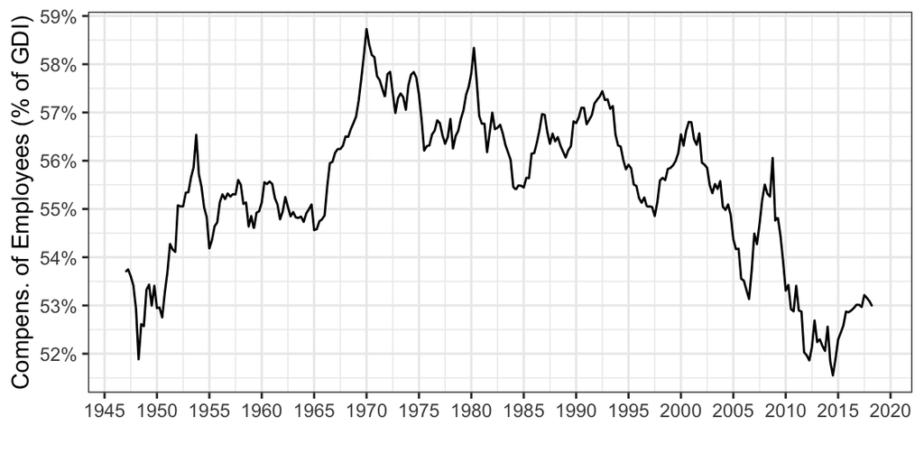

For our purposes, we only need to remember that the share of compensation of employees is approximately 2/3 of value added. Therefore, we will very often work with a Cobb-Douglas production function such that:
$$Y_t = A_t K_t^{1/3} L_t^{2/3}.$$
Lecture 2 will walk you through the Solow growth model, where we shall make heavy use of that Cobb-Douglas production function.

# Readings - To go further

[The Economics of Well Being, *Harvard Business Review*.](https://hbr.org/2012/01/the-economics-of-well-being)

[G.D.P. R.I.P., *The New York Times*, August 9, 2009.](https://search.proquest.com/hnpnewyorktimes/docview/1030670685/A9EF0C9A254D4699PQ/1?accountid=14512)

(Gated) [Keeping up with the Karumes, *The Economist*, October 29, 2015.](https://www.economist.com/news/finance-and-economics/21677223-new-study-shows-money-can-buy-you-happinessbut-only-fleetingly-others)

(More Difficult Read) [Abraham, Katharine G. “Distinguished Lecture on Economics in Government-What We Don’t Know Could Hurt Us: Some Reflections on the Measurement of Economic Activity.” Journal of Economic Perspectives 19, no. 3 (September 2005): 3–18.](https://doi.org/10.1257/089533005774357833)

[^1]: Note that we are assuming here that there are no “rents” in the economy, that is that nothing can be obtained without either labor or capital. This is not exactly true, as for example oil is clearly more valuable than the costs of extracting it for the soil. Land is another example of something that is preexisting, but nevertheless earns a payment. It is a good first-order approximation however, as most production in fact requires either labor of capital.
[^2]: In some textbooks (as well as in earlier versions of these lecture notes), imports are denoted by $IM$ instead of $M$.